# pepeCash

Sam Reeves

2/5/2021

# Description

## Introducing PEPECASH, a strange AltCoin based on the popular meme Pepe the Frog.

$$\\[0.2in]$$
Various trading card assets immortalized in the blockchain are issued, and people purchase them with PEPECASH. Each “Rare Pepe” features a different version of Pepe. This is a fork of BTCPAY Market v0.3.1. Visit rarepepedirectory.com for a full list of these signifiers of completely useless value.

$$\\[0.2in]$$
All data comes from the FiveThirtyEight githup repo data/rare-pepes/

More information: https://fivethirtyeight.com/features/pepe-the-frog-symbolism-cryptoart-blockchain/

For donations: 1AZ3D1fpaoGFyLREcxz9VxwqMxvwra17he
$$\\[0.2in]$$

```r
library(tidyverse)
library(lubridate)
```

```r
blocks <- read.csv("https://github.com/fivethirtyeight/data/raw/master/rare-pepes/blocks_timestamps.csv")
orderMatches <- read.csv("https://github.com/fivethirtyeight/data/raw/master/rare-pepes/ordermatches_all.csv")
```

# Exploration of Rare Pepes

Let’s take a look at the data. We have a list of all 26,038 orders filled between Sept 9, 2016 and February 2, 2018.

It is evident that people actually purchased PEPECASH with an accepted cryptocurrency, then they blew it on a set of 1438 distinct Rare Pepes.

```r
glimpse(orderMatches)
```

```
## Rows: 26,038
## Columns: 5
## $ Block            <int> 428940, 429221, 429221, 429228, 429228, 429398, 4293…
## $ ForwardAsset     <fct> RAREPEPE, SHITCOINCARD, RAREPEPE, SHITCOINCARD, RARE…
## $ ForwardQuantity  <dbl> 1, 230, 10, 3, 1, 12, 2, 1, 755, 1, 45, 1, 5, 10, 10…
## $ BackwardAsset    <fct> XCP, XCP, XCP, XCP, XCP, XCP, XCP, XCP, XCP, XCP, XC…
## $ BackwardQuantity <dbl> 2.00, 13.80, 15.00, 0.18, 1.50, 0.72, 3.00, 1.50, 45…
```

```r
as_datetime(head(blocks$Timestamp, n=1))
```

```
## [1] "2016-09-09 02:22:01 UTC"
```

```r
as_datetime(tail(blocks$Timestamp, n=1))
```

```
## [1] "2018-02-02 01:40:35 UTC"
```

```r
pepeCount <- orderMatches %>% count(ForwardAsset)

length(pepeCount[[1]])
```

```
## [1] 1438
```

# What are the most significant Rare Pepes in the set?

## Most often purchased Rare Pepes:

```r
head(arrange(pepeCount, desc(n)), n=10)
```

```
##    ForwardAsset    n
## 1      PEPECASH 3002
## 2           XCP 1739
## 3  RAREPEPEPRTY  247
## 4  SHITCOINCARD  181
## 5      HAIRPEPE  176
## 6     TROUTPEPE  160
## 7   TESTNETPEPE  152
## 8      RAREPEPE  151
## 9     PEPEPARTY  109
## 10      GOXPEPE  106
```

http://rarepepedirectory.com/wp-content/uploads/2016/09/pepecash3.jpg

## Largest single Rare Pepe orders

All minted PEPEHEXCHANT tokens were purchased at once. Presumably, participants felt that these would Rare Pepes with the largest order quantities would become coveted collectors’ items.

```r
head(arrange(orderMatches, desc(ForwardQuantity)), n=10)
```

```
##     Block ForwardAsset ForwardQuantity BackwardAsset BackwardQuantity
## 1  434495 PEPEHEXCHANT      1000000000           XCP        10.000000
## 2  434351  PEPEONECOIN       333333333           XCP        10.000000
## 3  443001  TESTNETPEPE       250000000           XCP         2.500000
## 4  435860  PEPEONECOIN       223049971           XCP         6.691499
## 5  433677  PEPEONECOIN       182827690           XCP         5.484831
## 6  434209  PEPEONECOIN       100000000           XCP         3.000000
## 7  444489 PEPEREPUBLIC       100000000           XCP         7.000000
## 8  442897  TESTNETPEPE        60000000           XCP         0.600000
## 9  443071  TESTNETPEPE        40000000           XCP         0.400000
## 10 445689 PEPEREPUBLIC        32821142           XCP         8.205286
```

Warning: extremely bad content!

http://rarepepedirectory.com/wp-content/uploads/2016/10/PEPEHEXCHANT.jpg

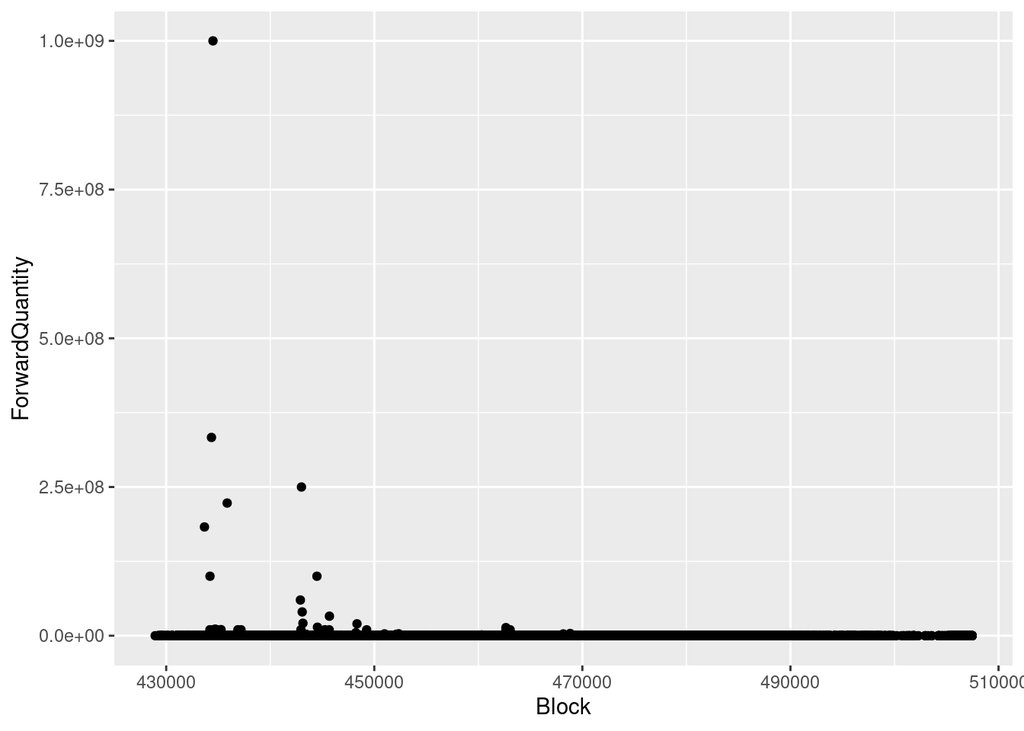

```r
ggplot(orderMatches, aes(x = Block, y = ForwardQuantity)) + geom_jitter()
```

# Conclusions:

Rare Pepes were kind of taken over by alt-right nutjobs. The meme is no longer just a silly comic, and so, PEPECASH will likely never be a significant mainstream coin. Though the project continues, it can be considered dead for practical purposes. Early on, people were willing to buy large quantities of these tokens, but the purchases never caught on.